# Data science per psicologi - demo 17.02

Corrado Caudek

2022-04-04

```r
suppressPackageStartupMessages({
  library("here")
  library("tidyverse")
  library("scales")
  library("bayesplot")
})

theme_set(bayesplot::theme_default(base_size = 12))
bayesplot::color_scheme_set("gray")
set.seed(84735)

knitr::opts_chunk$set(
  collapse = TRUE,
  tidy = 'styler',
  fig.width = 6,
  fig.asp = 0.618 # 1 / phi
)
```

# Metodo basato su griglia

Consideriamo un altro esempio del metodo basato su griglia per il calcolo della distribuzione a posteriori.

## Versione 1

### Distribuzione a priori

Consideriamo 20 lanci di una moneta equilibrata. Osserviamo 15 successi (“testa”). Vogliamo costruire la distribuzione a posteriori $p(\theta \mid y)$ per il parametro $\theta$ che rappresenta la probabilità di successo in una singola prova.

Decidiamo di usare una griglia con solo 11 valori possibili per $\theta$.

```r
theta <- seq(0, 1, length.out = 11)
```

A tali valori discreti di $\theta$ assegnamo le seguenti probabilità:

```r
prior <- c(0.0, 0.04, 0.08, 0.12, 0.16, 0.20, 0.16, 0.12, 0.08, 0.04, 0.0)
```

Creiamo il DataFrame `d` che contiene tale distribuzione di massa di probabilità:

```r
dd <- data.frame(theta, prior)
dd
```

```
##    theta prior
## 1    0.0  0.00
## 2    0.1  0.04
## 3    0.2  0.08
## 4    0.3  0.12
## 5    0.4  0.16
## 6    0.5  0.20
## 7    0.6  0.16
## 8    0.7  0.12
## 9    0.8  0.08
## 10   0.9  0.04
## 11   1.0  0.00
```

Una rappresentazione grafica della distribuzione a priori è la seguente:

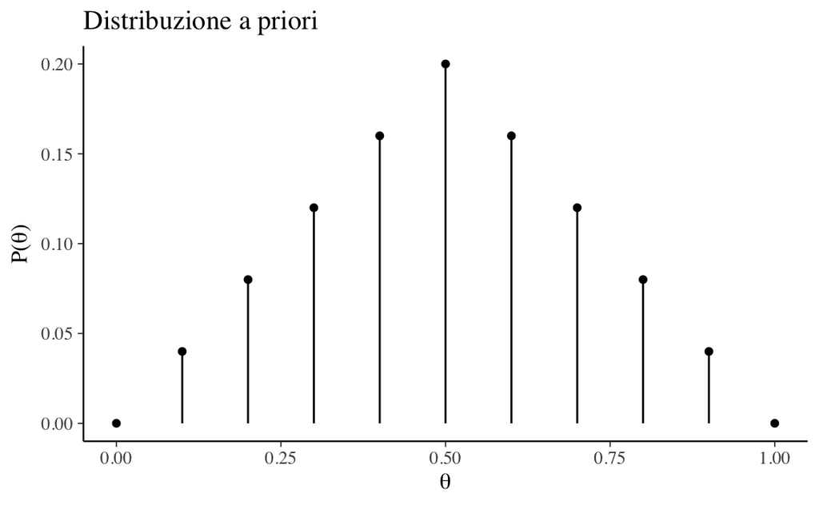

```r
p1 <- ggplot(dd, aes(x = theta, y = prior)) +
  geom_point() +
  geom_segment(aes(
    x = theta, xend = theta,
    y = prior, yend = 0
  )) +
  xlab(expression(theta)) +
  ylab(expression(paste("P(", theta, ")"))) +
  ggtitle("Distribuzione a priori")
p1
```

### Verosimiglianza

Per costruire la funzione di verosimiglianza usiamo il kernel della distribuzione binomiale:

```r
# likelihood
like <- function(theta, y, n) {
  theta^y * (1 - theta)^(n - y)
}

dd$likelihood <- like(dd$theta, 15, 20)
```

La funzione di verosimiglianza *non normalizzata*

```r
sum(dd$likelihood)
```

```
## [1] 3.070877e-05
```

è rappresentata nella figura:

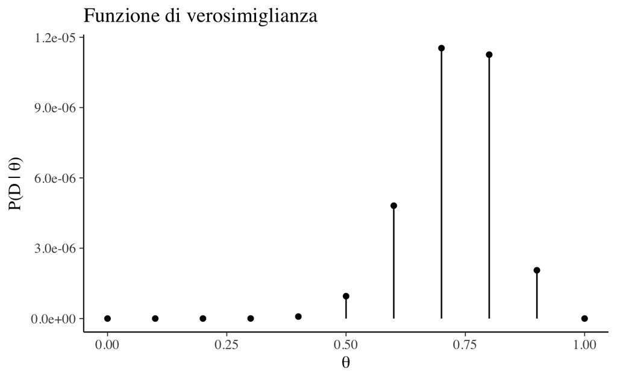

```r
p2 <- ggplot(dd, aes(x = theta, y = likelihood)) +
  geom_point() +
  geom_segment(aes(
    x = theta, xend = theta,
    y = likelihood, yend = 0
  )) +
  xlab(expression(theta)) +
  ylab(expression(paste("P(D | ", theta, ")"))) +
  ggtitle("Funzione di verosimiglianza")
p2
```

### Distribuzione a posteriori

La distribuzione a posteriori si ottiene semplicemente facendo il prodotto della distribuzione a priori e della verosimiglianza:

```r
dd$posterior <- dd$prior * dd$likelihood / sum(dd$prior * dd$likelihood)
```

La distribuzione a posteriori calcolata come indicato sopra è normalizzata. Un grafico è

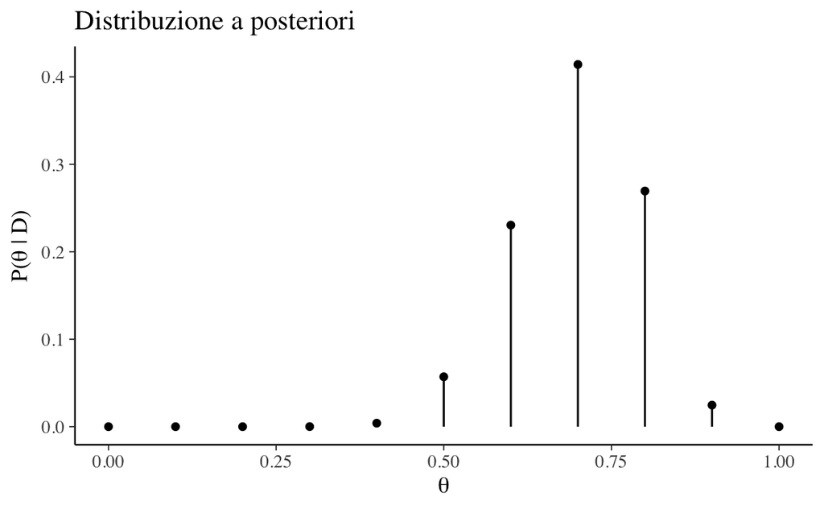

```r
p3 <- ggplot(dd, aes(x = theta, y = posterior)) +
  geom_point() +
  geom_segment(aes(x = theta, xend = theta, y = posterior, yend = 0)) +
  xlab(expression(theta)) +
  ylab(expression(paste("P(", theta, " | D)"))) +
  ggtitle("Distribuzione a posteriori")
p3
```

## Versione 2

Ripetiamo l’esercizio utilizzando le funzioni $\textsf{R}$.

Iniziamo con 11 punti, come in precedenza.

### Distribuzione a priori

```r
theta <- seq(0, 1, length.out = 11)
theta
```

```
##  [1] 0.0 0.1 0.2 0.3 0.4 0.5 0.6 0.7 0.8 0.9 1.0
```

```r
prior <- dbeta(theta, 2, 2) / sum(dbeta(theta, 2, 2))
prior
```

```
##  [1] 0.00000000 0.05454545 0.09696970 0.12727273 0.14545455 0.15151515
##  [7] 0.14545455 0.12727273 0.09696970 0.05454545 0.00000000
```

```r
sum(prior)
```

```
## [1] 1
```

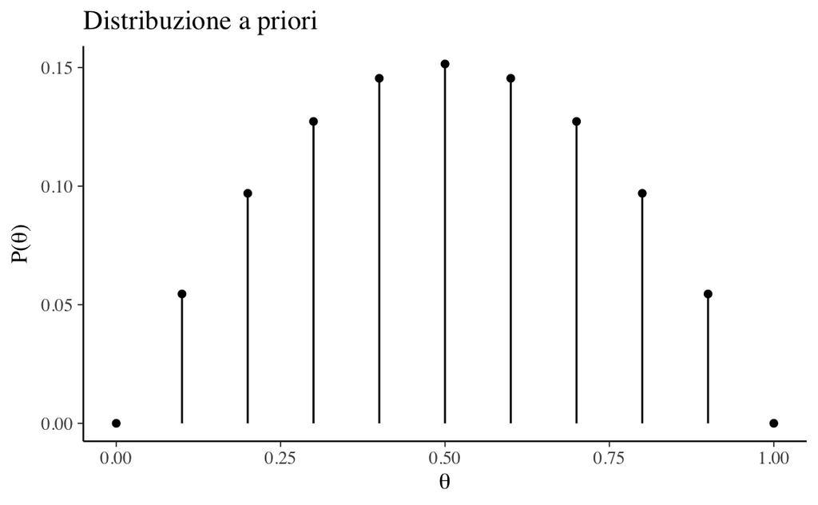

```r
tibble(x = theta, y = prior) %>%
  ggplot(aes(x = theta, y = y)) +
  geom_point() +
  geom_segment(aes(
    x = x, xend = x,
    y = y, yend = 0
  )) +
  xlab(expression(theta)) +
  ylab(expression(paste("P(", theta, ")"))) +
  ggtitle("Distribuzione a priori")
```

### Verosimiglianza

```r
like <- dbinom(15, 20, theta)
like
```

```
##  [1] 0.000000e+00 9.154957e-12 1.664729e-07 3.738977e-05 1.294494e-03
##  [6] 1.478577e-02 7.464702e-02 1.788631e-01 1.745595e-01 3.192136e-02
## [11] 0.000000e+00
```

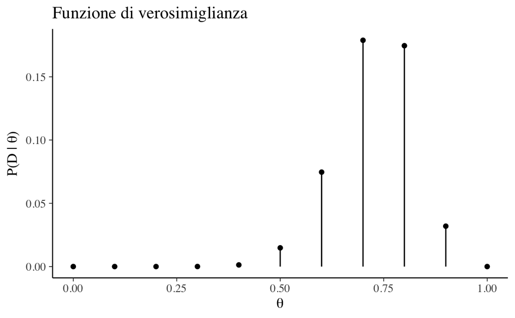

```r
tibble(x = theta, y = like) %>%
  ggplot(aes(x = x, y = y)) +
  geom_point() +
  geom_segment(aes(
    x = x, xend = x,
    y = y, yend = 0
  )) +
  xlab(expression(theta)) +
  ylab(expression(paste("P(D | ", theta, ")"))) +
  ggtitle("Funzione di verosimiglianza")
```

### Distribuzione a posteriori

```r
post <- prior * like / sum(prior * like)
post
```

```
##  [1] 0.000000e+00 9.125151e-12 2.949884e-07 8.695876e-05 3.440744e-03
##  [6] 4.093786e-02 1.984106e-01 4.159884e-01 3.093177e-01 3.181743e-02
## [11] 0.000000e+00
```

```r
sum(post)
```

```
## [1] 1
```

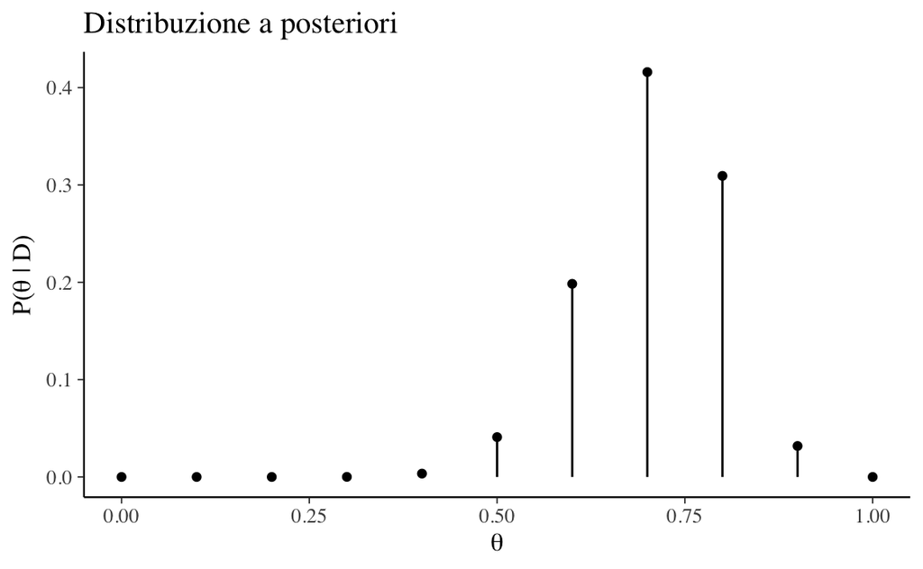

```r
tibble(x = theta, y = post) %>%
  ggplot(aes(x = x, y = y)) +
  geom_point() +
  geom_segment(aes(x = x, xend = x, y = y, yend = 0)) +
  xlab(expression(theta)) +
  ylab(expression(paste("P(", theta, " | D)"))) +
  ggtitle("Distribuzione a posteriori")
```

## Versione 3

È ovvio che aumentando il numero di punti possiamo rappresentare le varie distribuzioni con delle curve. A questo fine, rispetto alla versione 2, introduco due piccoli cambiamenti: cambio il numero di punti e utilizzo la funzione `geom_line()`.

### Distribuzione a priori

```r
theta <- seq(0, 1, length.out = 1e3)
```

```r
prior <- dbeta(theta, 2, 2) / sum(dbeta(theta, 2, 2))
```

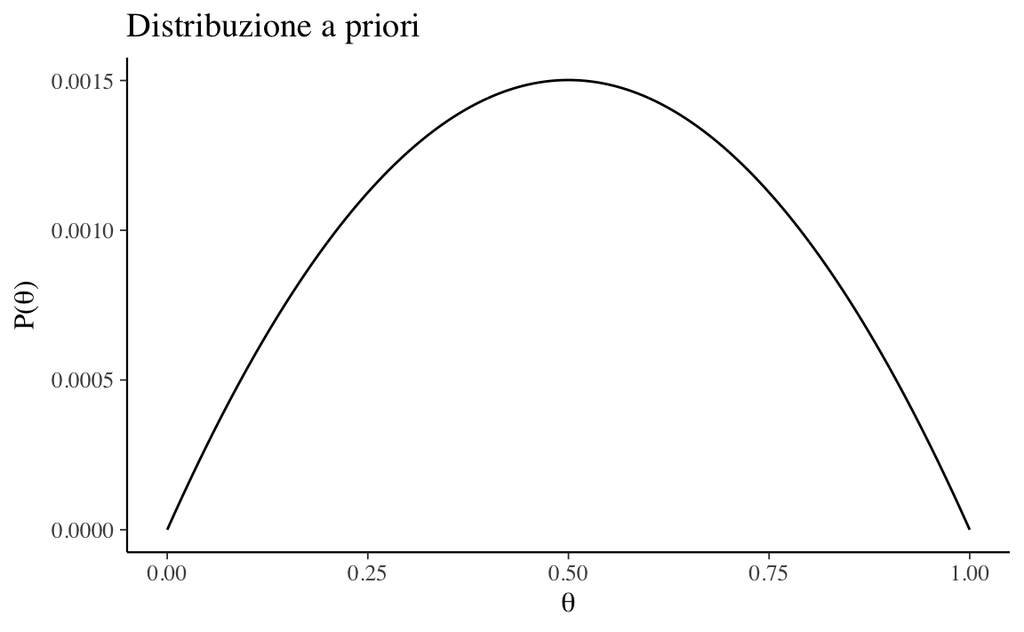

```r
tibble(x = theta, y = prior) %>%
  ggplot(aes(x = theta, y = y)) +
  geom_line() +
  xlab(expression(theta)) +
  ylab(expression(paste("P(", theta, ")"))) +
  ggtitle("Distribuzione a priori")
```

### Verosimiglianza

```r
like <- dbinom(15, 20, theta)
```

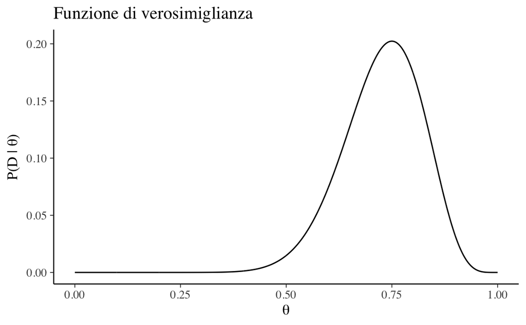

```r
tibble(x = theta, y = like) %>%
  ggplot(aes(x = x, y = y)) +
  geom_line() +
  xlab(expression(theta)) +
  ylab(expression(paste("P(D | ", theta, ")"))) +
  ggtitle("Funzione di verosimiglianza")
```

### Distribuzione a posteriori

```r
post <- prior * like / sum(prior * like)
```

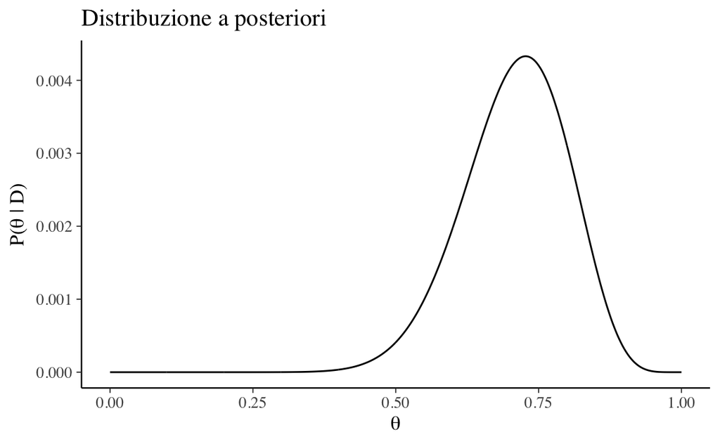

```r
tibble(x = theta, y = post) %>%
  ggplot(aes(x = x, y = y)) +
  geom_line() +
  xlab(expression(theta)) +
  ylab(expression(paste("P(", theta, " | D)"))) +
  ggtitle("Distribuzione a posteriori")
```